# Video Game Notebook in R by Suhaas

[figure not shown]

In this notebook, we will be talking about how video games have changed over the years and what specific correlations are. This data was collected by a Kaggle contributor that collected data of around 11,500 games with 11 different variables.

First let’s make a table to show what the variables are…

| **Variable:** | **Type:** | **Description:** |
| --- | --- | --- |
| Rank | Discrete Numerical | The order of the games |
| Name | Nominal Categorical | The name of the game |
| Platform | Nominal Categorical | The platform the game is played on |
| Year | Discrete Numerical | The year it was released |
| Genre | Nominal Categorical | The type of game it is |
| Publisher | Nominal Categorical | The company that made it |
| NA_Sales | Continuous Numerical | The total sales in North America |
| EU_Sales | Continuous Numerical | The total sales in Europe |
| JP_Sales | Continuous Numerical | The total sales in Japan |
| Other_Sales | Continuous Numerical | The total sales in other non-major countries |
| Global_Sales | Continuous Numerical | The total sales in the world |

**Potential Biases:**

- Regional Sales - This data set might have certain biases over how specific regions have more popularity in gaming and an overall spike in population.
- Age Bias - Since some games are older than others and are in the market for longer, they may make more sales than newer released games.
- Genre Bias: Certain people have their own bias towards their personal favorite genres they enjoy so the sample they take could influence the global/national sales of the product.

Overall there are many different types of biases that can influence a data set but these are the important ones that relate to this particular data set.

```r
# Load neccesary libraries
library(ggplot2)
library(dplyr)
library(tidyr)
```

Firstly, we have to load the necessary libraries in order for this project go through.

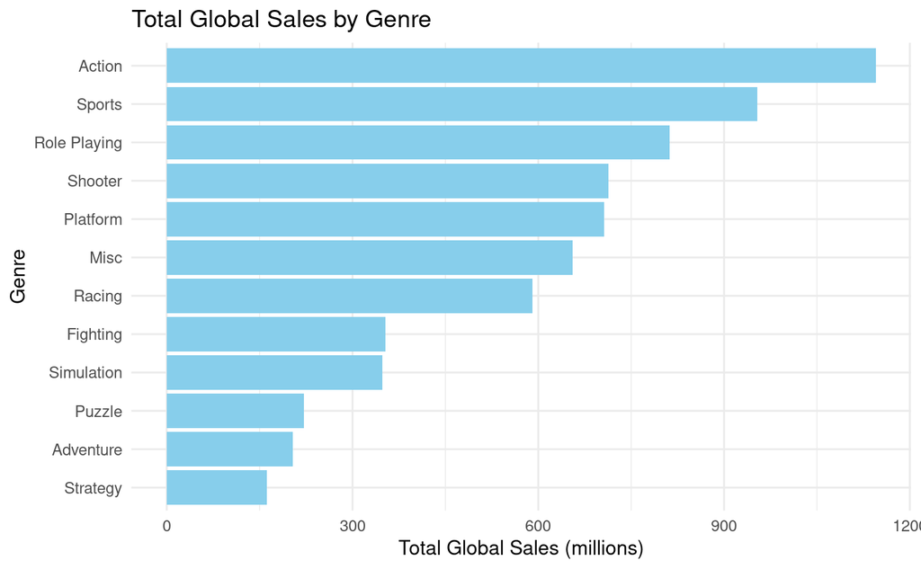

```r
# Make a variable that groups the sales by genre
sales_by_genre <- df %>%
  group_by(Genre) %>%
  summarize(Total_Global_Sales = sum(Global_Sales, na.rm = TRUE))

ggplot(sales_by_genre, aes(x = reorder(Genre, Total_Global_Sales), y = Total_Global_Sales)) +
  geom_bar(stat = "identity", fill = "skyblue") +
  coord_flip() +
  labs(title = "Total Global Sales by Genre", x = "Genre", y = "Total Global Sales (millions)") +
  theme_minimal()
```

This code creates a graph that shows what genre had the more sales. It is shown that action and sports are the top leading genres with action being number 1. If this data provided what age range bought these type of games, we could make a confident estimate of future purchases.

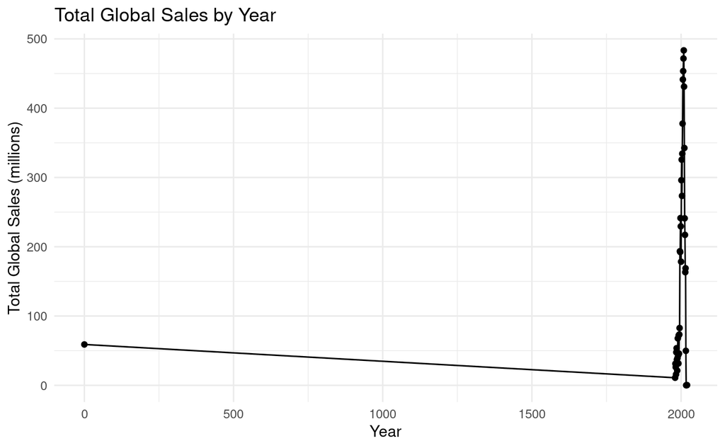

```r
# Make a variable that groups the sales by the year so we can create a graph that shows the spread of games bought throughout the years
sales_by_year <- df %>%
  group_by(Year) %>%
  summarize(Total_Global_Sales = sum(Global_Sales, na.rm = TRUE))
# Making the graph
ggplot(sales_by_year, aes(x = Year, y = Total_Global_Sales)) +
  geom_line() +
  geom_point() +
  labs(title = "Total Global Sales by Year", x = "Year", y = "Total Global Sales (millions)") +
  theme_minimal()
```

**Error Testing:** Seems like the data has multiple years (outliers) with the number “0” so it is being skewed to the left. To fix this we must filter out the 0’s only.

```r
# Filter the 0's out of the data
df_filtered <- df %>% filter(Year != "0")
```

Now we can make another variable that uses the filtered data set.

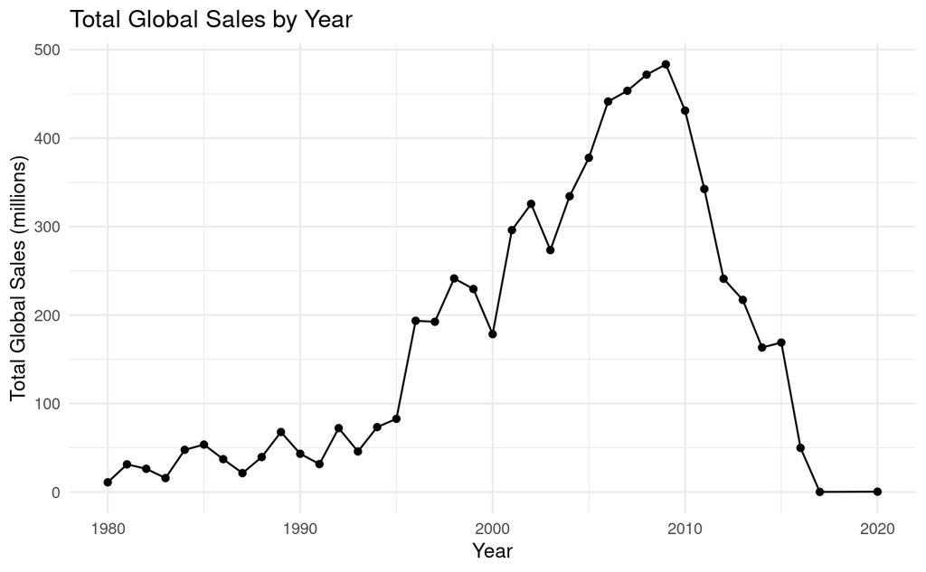

```r
# Create new variable because data is now filtered
sales_by_year <- df_filtered %>%
  group_by(Year) %>%
  summarize(Total_Global_Sales = sum(Global_Sales, na.rm = TRUE))

ggplot(sales_by_year, aes(x = Year, y = Total_Global_Sales)) +
  geom_line() +
  geom_point() +
  labs(title = "Total Global Sales by Year", x = "Year", y = "Total Global Sales (millions)") +
  theme_minimal()
```

This fixed graph shows the spread of the data that is now in proper order.

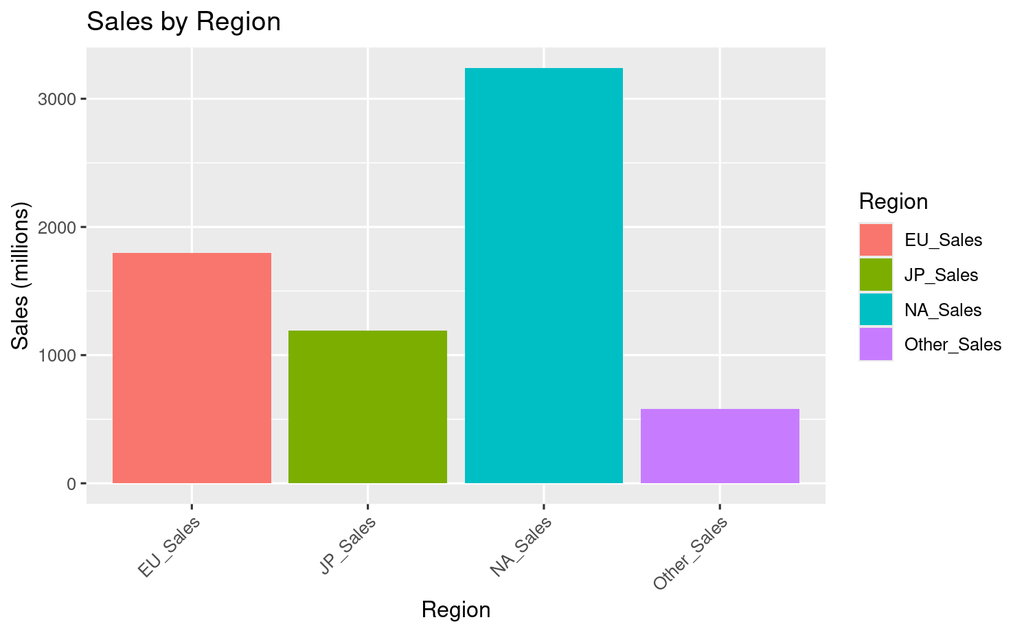

```r
# Make a group that shows the sales by region
sales_by_region <- df_filtered %>%
  summarize(NA_Sales = sum(NA_Sales, na.rm = TRUE),
            EU_Sales = sum(EU_Sales, na.rm = TRUE),
            JP_Sales = sum(JP_Sales, na.rm = TRUE),
            Other_Sales = sum(Other_Sales, na.rm = TRUE))

# Reshape the data to make a new variable
sales_by_region_long <- sales_by_region %>%
  pivot_longer(cols = everything(), names_to = "Region", values_to = "Sales")

# Create the actual bar graph
ggplot(sales_by_region_long, aes(x = Region, y = Sales, fill = Region)) +
  geom_bar(stat = "identity") +
  labs(title = "Sales by Region",
       x = "Region",
       y = "Sales (millions)") +
  theme(axis.text.x = element_text(angle = 45, hjust = 1))
```

After **creating** the graphs, we have to create a **model** that shows the **residuals** and the relation between North American Sales and Global Sales to see if we can predict the Global Sales through the NA Sales.

```r
model <- lm(Global_Sales ~ NA_Sales, data = df)

summary(model)
```

```
Call:
lm(formula = Global_Sales ~ NA_Sales, data = df)

Residuals:
     Min       1Q   Median       3Q      Max
-20.0434  -0.1185  -0.0668   0.0132  11.6198

Coefficients:
            Estimate Std. Error t value Pr(>|t|)
(Intercept) 0.086763   0.005891   14.73   <2e-16 ***
NA_Sales    1.792298   0.005996  298.92   <2e-16 ***
---
Signif. codes:  0 ‘***’ 0.001 ‘**’ 0.01 ‘*’ 0.05 ‘.’ 0.1 ‘ ’ 1

Residual standard error: 0.6037 on 11468 degrees of freedom
Multiple R-squared:  0.8863,    Adjusted R-squared:  0.8862
F-statistic: 8.935e+04 on 1 and 11468 DF,  p-value: < 2.2e-16
```

Now it is needed to make a **linear** **regression** line to see the line of best fit for the graph (can show an approximate estimation for sales in the future).

[figure not shown]

```r
model <- lm(Global_Sales ~ NA_Sales, data = df_filtered)

ggplot(df_filtered, aes(x = Global_Sales, y = NA_Sales)) +
  geom_point() +
  geom_smooth(method = "lm", se = FALSE) +
  labs(title = "The Effect of North American Sales on Global Sales", x = "North American Sales (millions)", y = "Global Sales (millions)")
```

In conclusion, this data has provided many **informational** models to provide a **deeper** understanding within the video game community. With the help of the data set, we can come to a conclusion that if North American sales increase, we can expect that future Global Sales will also increase.

**Problems occurred:** A variety of problems came about these graphs such as not enough variables given in the data set, specific data gone missing, more numerical/categorical data needed, etc. Even though there were problems we still formed a proper conclusion using a linear regression